# Zenith Abacus Estimation

Template for RMD from mosaic; most code from MCF, some from JS

February 18, 2016

Load libraries

Read in the data first, then combine Woodcock and Wiat and z-score the Standardized Test composite

```r
d <- read.csv("/Users/jsulliv1/Desktop/zenith all data_newhighlevela.csv")
d$condition <- factor(d$condition, levels=c("control","abacus"))
d$standardized <- rowMeans(d[,c("wiat","woodcock")],na.rm=TRUE)
```

# Descriptives and preliminaries

Summaries.

```r
d %>%
  select(standardized, ans, deviance, linr2, ordinality, year) %>%
  group_by(year) %>%
  do(tidy(summary(.))) %>%
  data.frame
```

```
##     year Var1          Var2              Freq
## 1      0       standardized Min.   :0.04651
## 2      0       standardized 1st Qu.:0.15302
## 3      0       standardized Median :0.19302
## 4      0       standardized Mean   :0.19596
## 5      0       standardized 3rd Qu.:0.23791
## 6      0       standardized Max.   :0.34279
## 7      0       standardized              <NA>
## 8      0                ans  Min.   : 5.000
## 9      0                ans  1st Qu.: 7.000
## 10     0                ans  Median : 8.000
## 11     0                ans  Mean   : 8.603
## 12     0                ans  3rd Qu.:10.000
## 13     0                ans  Max.   :15.000
## 14     0                ans       NA's   :8
```

[output cut: 154 more lines]

## Training effects: do for all to make sure no errors in datafile after adding new ANS measure

OK, now we test for effect of training for ANS. We can use a model b/c we have all 4 years:

```r
w.interaction <- lmer(ans ~ year  * condition + (subnum|year), data=d)
summary(w.interaction)
```

```
## Linear mixed model fit by REML ['lmerMod']
## Formula: ans ~ year * condition + (subnum | year)
##    Data: d
##
## REML criterion at convergence: 3174.8
##
## Scaled residuals:
##     Min      1Q  Median      3Q     Max
## -3.7358 -0.6458  0.0621  0.6416  3.1548
##
## Random effects:
##  Groups   Name        Variance  Std.Dev.  Corr
##  year     (Intercept) 7.291e-01 0.8538523
##           subnum      2.578e-07 0.0005078 -1.00
##  Residual             4.345e+00 2.0843955
## Number of obs: 734, groups:  year, 4
##
## Fixed effects:
##                      Estimate Std. Error t value
## (Intercept)           9.07548    0.68048  13.337
## year                  1.42299    0.36352   3.914
## conditionabacus       0.41163    0.25986   1.584
## year:conditionabacus  0.06249    0.13828   0.452
##
## Correlation of Fixed Effects:
##             (Intr) year   cndtnb
## year        -0.802
## conditinbcs -0.193  0.155
## yr:cndtnbcs  0.155 -0.192 -0.805
```

```r
wo.interaction<-lmer(ans ~ year + condition + (subnum|year), data=d)
anova(w.interaction, wo.interaction)
```

```
## refitting model(s) with ML (instead of REML)
```

```
## Data: d
## Models:
## wo.interaction: ans ~ year + condition + (subnum | year)
## w.interaction: ans ~ year * condition + (subnum | year)
##                Df    AIC    BIC  logLik deviance  Chisq Chi Df Pr(>Chisq)
## wo.interaction  7 3184.0 3216.2 -1585.0   3170.0
## w.interaction   8 3185.8 3222.6 -1584.9   3169.8 0.2063      1     0.6497
```

Now, we do t-tests by task to find differences between control and abacus groups. We will correct for multiple comparisons post-hoc, correcting for the # of comparisons per DV.

```r
tasks <- c("deviance","linr2","ans", "ordinality")

d %>%
  filter(year > 0) %>%
  gather(measure, value, deviance, linr2, ans, ordinality) %>%
  group_by(year, measure) %>%
  do(tidy(t.test(.$value[.$condition == "abacus"],
                 .$value[.$condition == "control"])))
```

```
## Source: local data frame [12 x 10]
## Groups: year, measure
##
##    year    measure    estimate  estimate1  estimate2  statistic    p.value
## 1     1   deviance -0.08016137  0.6653488  0.7455102 -1.6349326 0.10385750
## 2     1      linr2  0.01588989  0.3747674  0.3588776  0.5947372 0.55279248
## 3     1        ans  0.69743711 11.7790698 11.0816327  2.2972827 0.02280275
## 4     1 ordinality  0.02119839  0.8089535  0.7877551  2.1472626 0.03312995
## 5     2   deviance -0.11762626  0.6504545  0.7680808 -2.2387863 0.02637566
## 6     2      linr2  0.01030303  0.3572727  0.3469697  0.3780748 0.70582175
## 7     2        ans  0.18274583 12.5909091 12.4081633  0.6117240 0.54148377
## 8     2 ordinality  0.01416667  0.8011364  0.7869697  1.3926937 0.16539755
## 9     3   deviance -0.07276907  0.6596552  0.7324242 -1.4796581 0.14067668
## 10    3      linr2  0.06729363  0.3918391  0.3245455  2.3208574 0.02146247
## 11    3        ans  0.76331222 13.4367816 12.6734694  2.3766504 0.01850340
## 12    3 ordinality  0.01132358  0.8042529  0.7929293  1.1191883 0.26453958
## Variables not shown: parameter (dbl), conf.low (dbl), conf.high (dbl)
```

# Standardize predictors.

```r
# this is insane, but PCA will choke if the scaled variables have included in them the scaling attributes (and this is what R does by default).
sscale <- function (x) {as.numeric(scale(x))}

md <- d %>%
  gather(measure, value, deviance, linr2, ans, ordinality) %>%
  group_by(year, measure) %>%
  mutate(standardized.scale = sscale(standardized),
         value.scale = sscale(value),
         wiat.scale = sscale(wiat),
         woodcock.scale = sscale(woodcock),
         math.scale = sscale(math),
         placeval.scale = sscale(placeval),
         arith.scale = sscale(arith),
         mental.rot.scale = sscale(mental.rot),
         verbalwm.scale = sscale(verbalwm),
         spatialwm.scale = sscale(spatialwm),
         ravens.scale = sscale(ravens))
```

Now fit models. This uses the `broom` package - really very nifty.

NOTE, these are scaled values predicting scaled values.

```r
std.baseline.models <- md %>%
  group_by(year, measure) %>%
  filter(!(year == 0 & measure != "ans")) %>%
  do(tidy(lm(standardized.scale ~ value.scale, data = .))) %>%
  filter(term != "(Intercept)") %>%
  data.frame
std.baseline.models
```

```
##    year    measure        term      estimate  std.error   statistic
## 1     0        ans value.scale  0.2835177682 0.07174845  3.95155228
## 2     1   deviance value.scale -0.0736166477 0.07429885 -0.99081808
## 3     1      linr2 value.scale  0.1031406510 0.07410564  1.39180566
## 4     1        ans value.scale  0.1405556719 0.07376685  1.90540436
## 5     1 ordinality value.scale  0.0008627001 0.07449894  0.01158003
## 6     2   deviance value.scale -0.1447405155 0.07301173 -1.98242838
## 7     2      linr2 value.scale  0.1910128279 0.07337888  2.60310359
## 8     2        ans value.scale  0.1565563254 0.07326219  2.13693198
## 9     2 ordinality value.scale  0.2081562771 0.07257958  2.86797306
## 10    3   deviance value.scale -0.2283394329 0.07187531 -3.17688289
## 11    3      linr2 value.scale  0.2773777821 0.07093151  3.91050137
## 12    3        ans value.scale  0.1753649029 0.07301366  2.40180966
## 13    3 ordinality value.scale  0.2275793284 0.07188841  3.16573055
##         p.value
## 1  0.0001120430
## 2  0.3230898640
## 3  0.1656798389
## 4  0.0583040259
## 5  0.9907733616
## 6  0.0489197083
## 7  0.0099918231
## 8  0.0339314919
## 9  0.0046136812
## 10 0.0017460976
## 11 0.0001294263
## 12 0.0173148421
## 13 0.0018107944
```

Check year 3 correlations

```r
cor.test(d$standardized[d$year==3],d$linr2[d$year==3])
```

```
##
##  Pearson's product-moment correlation
##
## data:  d$standardized[d$year == 3] and d$linr2[d$year == 3]
## t = 3.9105, df = 184, p-value = 0.0001294
## alternative hypothesis: true correlation is not equal to 0
## 95 percent confidence interval:
##  0.1386516 0.4047527
## sample estimates:
##       cor
## 0.2770049
```

```r
cor.test(d$standardized[d$year==3],d$ans[d$year==3])
```

```
##
##  Pearson's product-moment correlation
##
## data:  d$standardized[d$year == 3] and d$ans[d$year == 3]
## t = 2.4018, df = 183, p-value = 0.01731
## alternative hypothesis: true correlation is not equal to 0
## 95 percent confidence interval:
##  0.03133461 0.31123227
## sample estimates:
##      cor
## 0.174813
```

```r
cor.test(d$standardized[d$year==3],d$deviance[d$year==3])
```

```
##
##  Pearson's product-moment correlation
##
## data:  d$standardized[d$year == 3] and d$deviance[d$year == 3]
## t = -3.1769, df = 184, p-value = 0.001746
## alternative hypothesis: true correlation is not equal to 0
## 95 percent confidence interval:
##  -0.36009736 -0.08700778
## sample estimates:
##        cor
## -0.2280325
```

```r
cor.test(d$standardized[d$year==3],d$ordinality[d$year==3])
```

```
##
##  Pearson's product-moment correlation
##
## data:  d$standardized[d$year == 3] and d$ordinality[d$year == 3]
## t = 3.1657, df = 184, p-value = 0.001811
## alternative hypothesis: true correlation is not equal to 0
## 95 percent confidence interval:
##  0.08621322 0.35940039
## sample estimates:
##       cor
## 0.2272734
```

And here are the full models.

```r
std.models <- md %>%
  group_by(year, measure) %>%
  filter(!(year == 0 & measure != "ans")) %>%
  do(tidy(lm(standardized.scale ~ value.scale +
               mental.rot.scale +
               verbalwm.scale +
               spatialwm.scale +
               ravens.scale +
               age + condition, data = .)))

options(dplyr.width = Inf)
print.data.frame(std.models)
```

```
##     year    measure             term      estimate  std.error    statistic
## 1      0        ans      (Intercept) -0.6506256609 0.88957776 -0.731387060
## 2      0        ans      value.scale  0.2182252315 0.07230343  3.018186384
## 3      0        ans mental.rot.scale -0.1166170494 0.07695852 -1.515323427
## 4      0        ans   verbalwm.scale  0.1951893348 0.08455928  2.308313522
## 5      0        ans  spatialwm.scale  0.2335416125 0.08898155  2.624607281
## 6      0        ans     ravens.scale  0.0147293774 0.07764811  0.189693959
## 7      0        ans              age  0.0970524714 0.13264013  0.731697642
## 8      0        ans  conditionabacus  0.0458409905 0.14509888  0.315929315
## 9      1   deviance      (Intercept)  0.0704332170 0.87808443  0.080212352
## 10     1   deviance      value.scale  0.0069503802 0.07071760  0.098283598
## 11     1   deviance mental.rot.scale  0.1684011132 0.08202233  2.053112944
## 12     1   deviance   verbalwm.scale  0.1168479389 0.07678948  1.521665910
## 13     1   deviance  spatialwm.scale  0.0875094913 0.07672455  1.140566990
## 14     1   deviance     ravens.scale  0.2263509344 0.08458085  2.676148647
```

[output cut: 195 more lines]

```r
gelb<-as.numeric(std.models$p.value)
small<-subset(std.models, gelb<.05)
print.data.frame(small)
```

```
##    year    measure             term  estimate  std.error statistic
## 1     0        ans      value.scale 0.2182252 0.07230343  3.018186
## 2     0        ans   verbalwm.scale 0.1951893 0.08455928  2.308314
## 3     0        ans  spatialwm.scale 0.2335416 0.08898155  2.624607
## 4     1   deviance mental.rot.scale 0.1684011 0.08202233  2.053113
## 5     1   deviance     ravens.scale 0.2263509 0.08458085  2.676149
## 6     1      linr2 mental.rot.scale 0.1669835 0.08228118  2.029425
## 7     1      linr2     ravens.scale 0.2274778 0.08449940  2.692064
## 8     1        ans mental.rot.scale 0.1645005 0.08149432  2.018552
## 9     1        ans     ravens.scale 0.2280386 0.08392056  2.717315
## 10    1 ordinality mental.rot.scale 0.1689034 0.08172022  2.066849
## 11    1 ordinality     ravens.scale 0.2179445 0.08476923  2.571033
## 12    1 ordinality  conditionabacus 0.2931081 0.14707403  1.992929
## 13    2   deviance     ravens.scale 0.2693149 0.08271429  3.255965
## 14    2      linr2     ravens.scale 0.2806527 0.08098731  3.465391
```

[output cut: 39 more lines]

And make pretty plot.

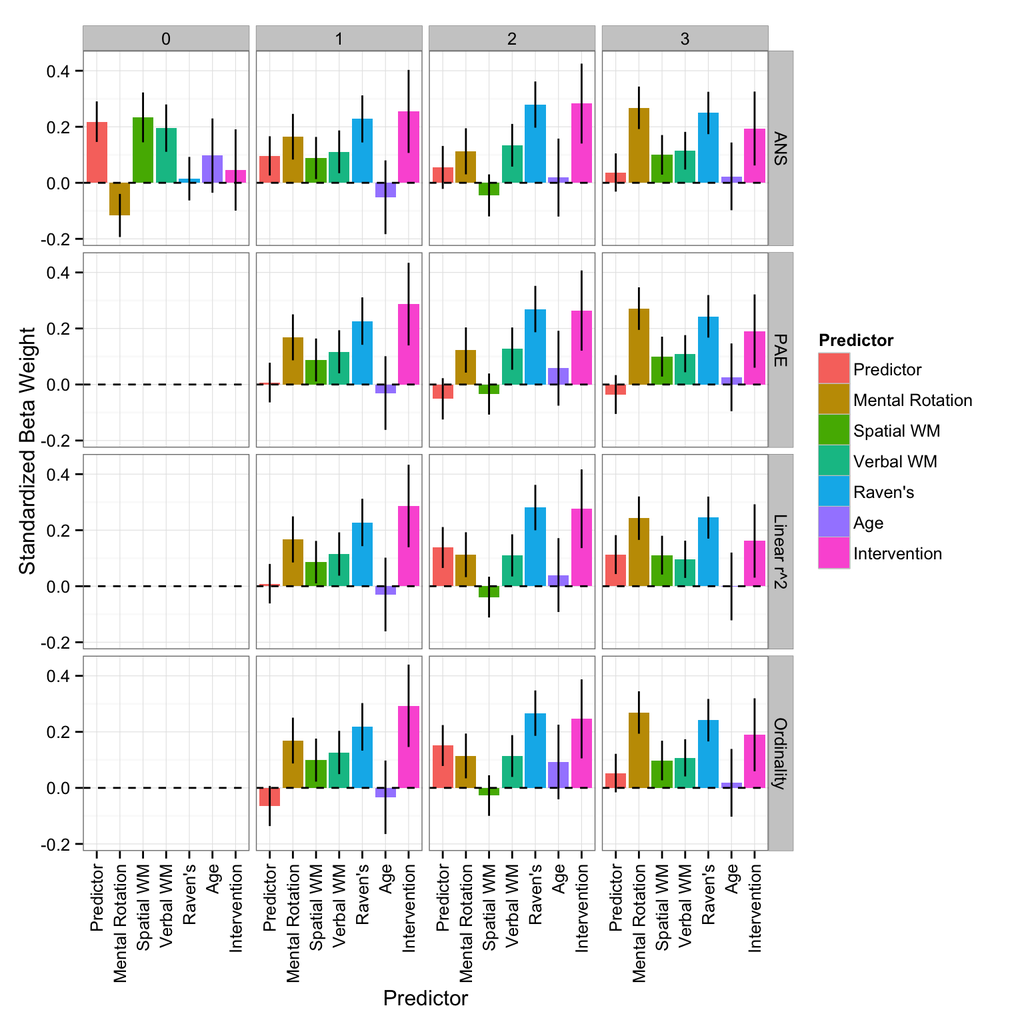

```r
std.models$term <- factor(std.models$term,
                           levels = c("(Intercept)",
                                      "value.scale", "mental.rot.scale",
                                      "spatialwm.scale", "verbalwm.scale",
                                      "ravens.scale","age", "conditionabacus"),
                           labels = c("Intercept",
                                      "Predictor", "Mental Rotation",
                                      "Spatial WM", "Verbal WM",
                                      "Raven's", "Age", "Intervention"))

std.models$measure <- factor(std.models$measure,
                              levels = c("ans","deviance","linr2","ordinality"),
                              labels = c("ANS","PAE","Linear r^2",
                                         "Ordinality"))

qplot(term, estimate,
      fill = term,
      ymin = estimate - std.error, ymax = estimate + std.error,
      geom = c("bar", "linerange"), stat = "identity",
      facets = measure ~ year,
      data=filter(std.models, term != "Intercept")) +
  geom_hline(yintercept=0, lty=2) +
  xlab("Predictor") +
  ylab("Standardized Beta Weight") +
  scale_fill_discrete(name="Predictor") +
  theme(axis.text.x = element_text(angle = 90, vjust=.5, hjust = 1))
```

# Add PCA to the dataset.

```r
# need this to get around standard evals
pc1 <- function(x,y,z,m,n) {
  sscale(as.numeric(prcomp(~x + y + z + m + n)$x[,1]))
}

# need to filter to complete cases
pmd <- md %>%
  filter(complete.cases(wiat.scale, woodcock.scale, math.scale,
                        placeval.scale, arith.scale)) %>%
  mutate(pc1 = pc1(wiat.scale, woodcock.scale, math.scale,
                   placeval.scale, arith.scale))
```

PCA Models and plot.

```r
pca.baseline.models <- pmd %>%
  group_by(year, measure) %>%
  filter(!(year == 0 & measure != "ans")) %>%
  do(tidy(lm(pc1 ~ value.scale, data = .))) %>%
  filter(term != "(Intercept)") %>%
  data.frame
pca.baseline.models
```

```
##    year    measure        term   estimate  std.error statistic
## 1     0        ans value.scale  0.2962959 0.07602183  3.897510
## 2     1   deviance value.scale  0.1676604 0.07346686  2.282123
## 3     1      linr2 value.scale -0.1581167 0.07354619 -2.149897
## 4     1        ans value.scale -0.1966438 0.07401355 -2.656861
## 5     1 ordinality value.scale -0.1054681 0.07430609 -1.419374
## 6     2   deviance value.scale  0.1873279 0.07311760  2.562009
## 7     2      linr2 value.scale -0.2497652 0.07302858 -3.420102
## 8     2        ans value.scale -0.1928887 0.07618651 -2.531795
## 9     2 ordinality value.scale -0.1914047 0.07492045 -2.554772
## 10    3   deviance value.scale  0.2476530 0.07146468  3.465390
## 11    3      linr2 value.scale -0.3378703 0.06971814 -4.846232
## 12    3        ans value.scale -0.1938091 0.07347173 -2.637873
## 13    3 ordinality value.scale -0.2735804 0.07165864 -3.817828
##         p.value
## 1  1.484350e-04
## 2  2.364572e-02
## 3  3.289062e-02
## 4  8.592132e-03
## 5  1.575100e-01
## 6  1.122584e-02
## 7  7.744574e-04
## 8  1.220826e-02
## 9  1.145338e-02
## 10 6.603674e-04
## 11 2.684857e-06
## 12 9.069055e-03
## 13 1.844388e-04
```

```r
pca.models <- pmd %>%
  group_by(year, measure) %>%
  filter(!(year == 0 & measure != "ans")) %>%
  do(tidy(lm(pc1 ~ value.scale +
               mental.rot.scale +
               verbalwm.scale +
               spatialwm.scale +
               ravens.scale +
               age + condition, data = .)))

options(dplyr.width = Inf)

print.data.frame(pca.models)
```

```
##     year    measure             term     estimate  std.error    statistic
## 1      0        ans      (Intercept) -1.953794634 0.90426781 -2.160637152
## 2      0        ans      value.scale  0.185073990 0.07202341  2.569636453
## 3      0        ans mental.rot.scale -0.037090110 0.07920689 -0.468268717
## 4      0        ans   verbalwm.scale  0.204302956 0.08355549  2.445117199
## 5      0        ans  spatialwm.scale  0.276633614 0.08923259  3.100140919
## 6      0        ans     ravens.scale  0.130131396 0.08337201  1.560852265
## 7      0        ans              age  0.286632418 0.13536259  2.117515728
## 8      0        ans  conditionabacus  0.114814689 0.14630991  0.784736234
## 9      1   deviance      (Intercept)  0.393256073 0.86642719  0.453882426
## 10     1   deviance      value.scale  0.076369306 0.06956242  1.097852922
## 11     1   deviance mental.rot.scale -0.137902965 0.08062877 -1.710344341
## 12     1   deviance   verbalwm.scale -0.154817774 0.07547741 -2.051180128
## 13     1   deviance  spatialwm.scale -0.137621074 0.07537677 -1.825775798
## 14     1   deviance     ravens.scale -0.215687795 0.08310873 -2.595248244
```

[output cut: 195 more lines]

```r
gelb2<-as.numeric(pca.models$p.value)
small2<-subset(pca.models, gelb2<.05)
print.data.frame(small2)
```

```
##    year    measure             term   estimate  std.error statistic
## 1     0        ans      (Intercept) -1.9537946 0.90426781 -2.160637
## 2     0        ans      value.scale  0.1850740 0.07202341  2.569636
## 3     0        ans   verbalwm.scale  0.2043030 0.08355549  2.445117
## 4     0        ans  spatialwm.scale  0.2766336 0.08923259  3.100141
## 5     0        ans              age  0.2866324 0.13536259  2.117516
## 6     1   deviance   verbalwm.scale -0.1548178 0.07547741 -2.051180
## 7     1   deviance     ravens.scale -0.2156878 0.08310873 -2.595248
## 8     1      linr2  spatialwm.scale -0.1479310 0.07442020 -1.987780
## 9     1      linr2     ravens.scale -0.2142894 0.08303426 -2.580734
## 10    1        ans      value.scale -0.1571172 0.06943376 -2.262835
## 11    1        ans   verbalwm.scale -0.1529966 0.07448678 -2.054010
## 12    1        ans  spatialwm.scale -0.1555421 0.07353187 -2.115302
## 13    1        ans     ravens.scale -0.2105281 0.08197194 -2.568295
## 14    1 ordinality   verbalwm.scale -0.1573712 0.07629260 -2.062733
```

[output cut: 71 more lines]

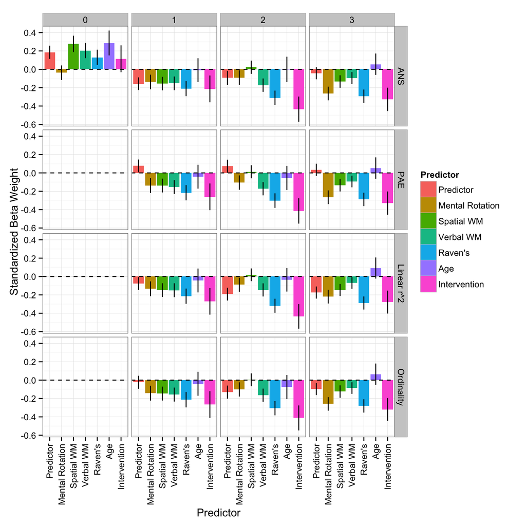

```r
pca.models$term <- factor(pca.models$term,
                          levels = c("(Intercept)",
                                     "value.scale", "mental.rot.scale",
                                     "spatialwm.scale", "verbalwm.scale",
                                     "ravens.scale","age", "conditionabacus"),
                          labels = c("Intercept",
                                     "Predictor", "Mental Rotation",
                                     "Spatial WM", "Verbal WM",
                                     "Raven's", "Age", "Intervention"))

pca.models$measure <- factor(pca.models$measure,
                              levels = c("ans","deviance","linr2","ordinality"),
                              labels = c("ANS","PAE","Linear r^2",
                                         "Ordinality"))

qplot(term, estimate,
      fill = term,
      ymin = estimate - std.error, ymax = estimate + std.error,
      geom = c("bar", "linerange"), stat = "identity",
      facets = measure ~ year,
      data=filter(pca.models, term != "Intercept")) +
  geom_hline(yintercept=0, lty=2) +
  xlab("Predictor") +
  ylab("Standardized Beta Weight") +
  scale_fill_discrete(name="Predictor") +
  theme(axis.text.x = element_text(angle = 90, vjust=.5, hjust = 1))
```

## Breaking down the models (not required, but helpful to ensure no code glitches)

Now for the guts of one of the models, just an example from year 0, ANS. This uses ANOVA for model comparison.

```r
## run models
# note, the filtering expression gets the model out of the same data frame that we used for the figure
# std.models <- md %>%
#   group_by(year, measure) %>%
#   filter(!(year == 0 & measure != "ans")) %>%
#   do(tidy(lm(standardized.scale ~ value.scale +
#                mental.rot.scale +
#                verbalwm.scale +
#                spatialwm.scale +
#                ravens.scale +
#                age + condition, data = .)))

model1 <- lm(standardized.scale ~ value.scale + mental.rot.scale + verbalwm.scale +
              spatialwm.scale + ravens.scale +  age + condition,
             data = filter(md, year == 0, measure == "ans",
                           complete.cases(value.scale)))
model2 <- lm(standardized.scale ~ mental.rot.scale + verbalwm.scale +
              spatialwm.scale + ravens.scale +  age + condition,
             data = filter(md, year == 0, measure == "ans",
                           complete.cases(value.scale)))
summary(model1)
```

```
##
## Call:
## lm(formula = standardized.scale ~ value.scale + mental.rot.scale +
##     verbalwm.scale + spatialwm.scale + ravens.scale + age + condition,
##     data = filter(md, year == 0, measure == "ans", complete.cases(value.scale)))
##
## Residuals:
##      Min       1Q   Median       3Q      Max
## -2.40468 -0.53978 -0.03563  0.61821  2.52885
##
## Coefficients:
##                  Estimate Std. Error t value Pr(>|t|)
## (Intercept)      -0.65063    0.88958  -0.731  0.46568
## value.scale       0.21823    0.07230   3.018  0.00299 **
## mental.rot.scale -0.11662    0.07696  -1.515  0.13178
## verbalwm.scale    0.19519    0.08456   2.308  0.02234 *
## spatialwm.scale   0.23354    0.08898   2.625  0.00957 **
## ravens.scale      0.01473    0.07765   0.190  0.84980
## age               0.09705    0.13264   0.732  0.46549
## conditionabacus   0.04584    0.14510   0.316  0.75249
## ---
## Signif. codes:  0 '***' 0.001 '**' 0.01 '*' 0.05 '.' 0.1 ' ' 1
##
## Residual standard error: 0.8989 on 151 degrees of freedom
##   (20 observations deleted due to missingness)
## Multiple R-squared:  0.2281, Adjusted R-squared:  0.1923
## F-statistic: 6.374 on 7 and 151 DF,  p-value: 1.423e-06
```

```r
summary(model2)
```

```
##
## Call:
## lm(formula = standardized.scale ~ mental.rot.scale + verbalwm.scale +
##     spatialwm.scale + ravens.scale + age + condition, data = filter(md,
##     year == 0, measure == "ans", complete.cases(value.scale)))
##
## Residuals:
##      Min       1Q   Median       3Q      Max
## -2.34388 -0.60553 -0.04901  0.53362  2.44016
##
## Coefficients:
##                  Estimate Std. Error t value Pr(>|t|)
## (Intercept)      -0.73367    0.91256  -0.804  0.42267
## mental.rot.scale -0.10336    0.07886  -1.311  0.19192
## verbalwm.scale    0.18652    0.08674   2.150  0.03310 *
## spatialwm.scale   0.28936    0.08933   3.239  0.00147 **
## ravens.scale      0.03301    0.07945   0.415  0.67841
## age               0.10756    0.13609   0.790  0.43055
## conditionabacus   0.07435    0.14860   0.500  0.61756
## ---
## Signif. codes:  0 '***' 0.001 '**' 0.01 '*' 0.05 '.' 0.1 ' ' 1
##
## Residual standard error: 0.9226 on 152 degrees of freedom
##   (20 observations deleted due to missingness)
## Multiple R-squared:  0.1815, Adjusted R-squared:  0.1492
## F-statistic: 5.618 on 6 and 152 DF,  p-value: 2.721e-05
```

```r
anova(model1, model2)
```

```
## Analysis of Variance Table
##
## Model 1: standardized.scale ~ value.scale + mental.rot.scale + verbalwm.scale +
##     spatialwm.scale + ravens.scale + age + condition
## Model 2: standardized.scale ~ mental.rot.scale + verbalwm.scale + spatialwm.scale +
##     ravens.scale + age + condition
##   Res.Df    RSS Df Sum of Sq      F   Pr(>F)
## 1    151 122.02
## 2    152 129.38 -1   -7.3612 9.1094 0.002986 **
## ---
## Signif. codes:  0 '***' 0.001 '**' 0.01 '*' 0.05 '.' 0.1 ' ' 1
```

```r
# also note that p value for the anova is the same as the coefficient p value in the models data frame
filter(std.models, year == 0, measure == "ANS")
```

```
## Source: local data frame [8 x 7]
## Groups: year, measure
##
##   year measure            term    estimate  std.error  statistic
## 1    0     ANS       Intercept -0.65062566 0.88957776 -0.7313871
## 2    0     ANS       Predictor  0.21822523 0.07230343  3.0181864
## 3    0     ANS Mental Rotation -0.11661705 0.07695852 -1.5153234
## 4    0     ANS       Verbal WM  0.19518933 0.08455928  2.3083135
## 5    0     ANS      Spatial WM  0.23354161 0.08898155  2.6246073
## 6    0     ANS         Raven's  0.01472938 0.07764811  0.1896940
## 7    0     ANS             Age  0.09705247 0.13264013  0.7316976
## 8    0     ANS    Intervention  0.04584099 0.14509888  0.3159293
##       p.value
## 1 0.465676248
## 2 0.002985759
## 3 0.131781047
## 4 0.022338877
## 5 0.009566575
## 6 0.849803710
## 7 0.465487176
## 8 0.752492421
```

Year 0 Analyses by JS, to check betas

```
##
## Call:
## lm(formula = standardized.scale ~ ans.scale + mental.rot.scale +
##     verbalwm.scale + spatialwm.scale + ravens.scale + age + condition,
##     data = yc0)
##
## Residuals:
##      Min       1Q   Median       3Q      Max
## -2.41814 -0.54280 -0.03582  0.62167  2.54301
##
## Coefficients:
##                  Estimate Std. Error t value Pr(>|t|)
## (Intercept)      -0.67403    0.89462  -0.753  0.45237
## ans.scale         0.22643    0.07502   3.018  0.00299 **
## mental.rot.scale -0.11615    0.07665  -1.515  0.13178
## verbalwm.scale    0.19810    0.08582   2.308  0.02234 *
## spatialwm.scale   0.23568    0.08980   2.625  0.00957 **
## ravens.scale      0.01510    0.07959   0.190  0.84980
## age               0.09760    0.13338   0.732  0.46549
## conditionabacus   0.04610    0.14591   0.316  0.75249
## ---
## Signif. codes:  0 '***' 0.001 '**' 0.01 '*' 0.05 '.' 0.1 ' ' 1
##
## Residual standard error: 0.904 on 151 degrees of freedom
##   (3 observations deleted due to missingness)
## Multiple R-squared:  0.2281, Adjusted R-squared:  0.1923
## F-statistic: 6.374 on 7 and 151 DF,  p-value: 1.423e-06
```

```
##
## Call:
## lm(formula = standardized.scale ~ mental.rot.scale + verbalwm.scale +
##     spatialwm.scale + ravens.scale + age + condition, data = yc0)
##
## Residuals:
##      Min       1Q   Median       3Q      Max
## -2.35700 -0.60892 -0.04928  0.53661  2.45382
##
## Coefficients:
##                  Estimate Std. Error t value Pr(>|t|)
## (Intercept)      -0.75985    0.91771  -0.828  0.40897
## mental.rot.scale -0.10295    0.07854  -1.311  0.19192
## verbalwm.scale    0.18931    0.08803   2.150  0.03310 *
## spatialwm.scale   0.29200    0.09015   3.239  0.00147 **
## ravens.scale      0.03383    0.08144   0.415  0.67841
## age               0.10816    0.13685   0.790  0.43055
## conditionabacus   0.07477    0.14944   0.500  0.61756
## ---
## Signif. codes:  0 '***' 0.001 '**' 0.01 '*' 0.05 '.' 0.1 ' ' 1
##
## Residual standard error: 0.9278 on 152 degrees of freedom
##   (3 observations deleted due to missingness)
## Multiple R-squared:  0.1815, Adjusted R-squared:  0.1492
## F-statistic: 5.618 on 6 and 152 DF,  p-value: 2.721e-05
```

```
## Analysis of Variance Table
##
## Model 1: standardized.scale ~ ans.scale + mental.rot.scale + verbalwm.scale +
##     spatialwm.scale + ravens.scale + age + condition
## Model 2: standardized.scale ~ mental.rot.scale + verbalwm.scale + spatialwm.scale +
##     ravens.scale + age + condition
##   Res.Df    RSS Df Sum of Sq      F   Pr(>F)
## 1    151 123.39
## 2    152 130.84 -1   -7.4439 9.1094 0.002986 **
## ---
## Signif. codes:  0 '***' 0.001 '**' 0.01 '*' 0.05 '.' 0.1 ' ' 1
```